```r
library(arules)
```

```r
library(arulesViz)
library("RColorBrewer")
str(df)
```

```
## function (x, df1, df2, ncp, log = FALSE)
```

(2 points)Read the file groceries which contains data about transactions made in the market. Make the data usable for Association Rules Mining. (Hint. You can use function read.transactions) plot the data to see what are the first 5 most frequent items

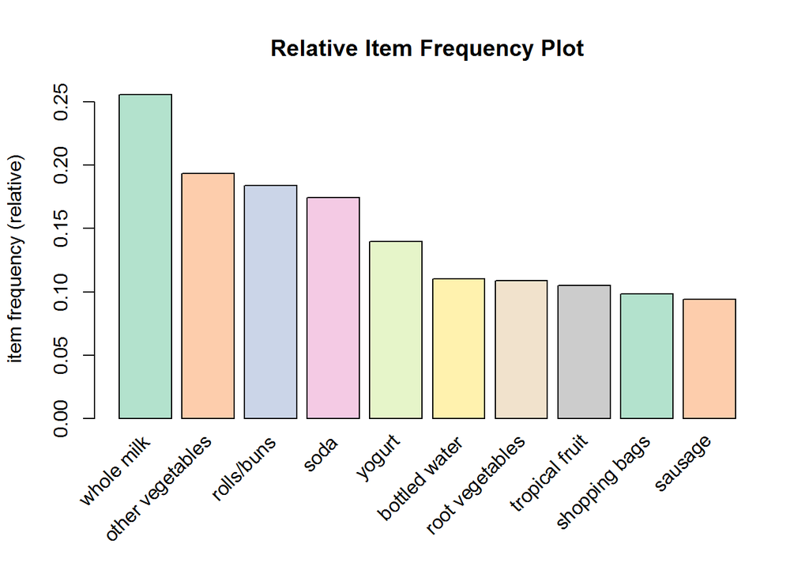

```r
txn <- read.transactions("groceries.csv",rm.duplicates = FALSE, cols = NULL, sep = ",")
itemFrequencyPlot(txn,
   topN=10,
   col=brewer.pal(8,'Pastel2'),
   main='Relative Item Frequency Plot')
```

Most frequent five items are whole milk, other vegetables, rolls/buns, soda and yogurt.

(5 points) Using appriori algorithm, create the rules by setting the support to be 0.005 and confidence to be 0.1 Set the length of the rules to be 4. Interpret the meaning of support and confidence.

```r
rules <- apriori(txn, parameter = list(minlen = 4, maxlen = 4, supp = 0.005, conf = 0.1))
```

```
## Apriori
##
## Parameter specification:
##  confidence minval smax arem  aval originalSupport maxtime support minlen
##         0.1    0.1    1 none FALSE            TRUE       5   0.005      4
##  maxlen target   ext
##       4  rules FALSE
##
## Algorithmic control:
##  filter tree heap memopt load sort verbose
##     0.1 TRUE TRUE  FALSE TRUE    2    TRUE
##
## Absolute minimum support count: 49
##
## set item appearances ...[0 item(s)] done [0.00s].
## set transactions ...[169 item(s), 9835 transaction(s)] done [0.01s].
## sorting and recoding items ... [120 item(s)] done [0.00s].
## creating transaction tree ... done [0.00s].
## checking subsets of size 1 2 3 4
```

```
##  done [0.00s].
## writing ... [48 rule(s)] done [0.00s].
## creating S4 object  ... done [0.00s].
```

(7 points) Inspect the first 5 rules. Sort them by support in descending order. Interpret the first 2 rules. What is the meaning of support, comfidence and lift?

```r
inspect(rules[1:5])
```

```
##     lhs                        rhs                         support confidence     lift count
## [1] {fruit/vegetable juice,
##      other vegetables,
##      yogurt}                => {whole milk}            0.005083884  0.6172840 2.415833    50
## [2] {fruit/vegetable juice,
##      whole milk,
##      yogurt}                => {other vegetables}      0.005083884  0.5376344 2.778578    50
## [3] {fruit/vegetable juice,
##      other vegetables,
##      whole milk}            => {yogurt}                0.005083884  0.4854369 3.479790    50
## [4] {other vegetables,
##      whole milk,
##      yogurt}                => {fruit/vegetable juice} 0.005083884  0.2283105 3.158135    50
## [5] {other vegetables,
##      root vegetables,
##      whipped/sour cream}    => {whole milk}            0.005185562  0.6071429 2.376144    51
```

```r
rules_df <- as(rules, "data.frame")
rules_df[order(-rules_df$support),]
```

```
##                                                                    rules
## 37             {other vegetables,root vegetables,yogurt} => {whole milk}
## 38             {root vegetables,whole milk,yogurt} => {other vegetables}
## 39             {other vegetables,root vegetables,whole milk} => {yogurt}
## 40             {other vegetables,whole milk,yogurt} => {root vegetables}
## 33              {other vegetables,tropical fruit,yogurt} => {whole milk}
## 34              {tropical fruit,whole milk,yogurt} => {other vegetables}
## 35              {other vegetables,tropical fruit,whole milk} => {yogurt}
## 36              {other vegetables,whole milk,yogurt} => {tropical fruit}
## 29     {other vegetables,root vegetables,tropical fruit} => {whole milk}
## 30     {root vegetables,tropical fruit,whole milk} => {other vegetables}
## 31     {other vegetables,tropical fruit,whole milk} => {root vegetables}
## 32     {other vegetables,root vegetables,whole milk} => {tropical fruit}
## 41         {other vegetables,rolls/buns,root vegetables} => {whole milk}
## 42         {rolls/buns,root vegetables,whole milk} => {other vegetables}
```

[output cut: 83 more lines]

1 {fruit/vegetable juice, other vegetables, yogurt} => {whole milk} Confidence shows that there is 0.61 probability that we will have whole milk bought given the customer bought the items on the left. Lift ratio shows how effective is the rule finding consequents (confidence / the overall probabilty of the right side). The more frequent is the itemset on the right, the lower is the lift ratio and the higher is the confidence, the higher the lift. Support shows overall impact. The probability that the itemset will occur is 0.005.

2 {fruit/vegetable juice, whole milk, yogurt} => {other vegetables} Confidence shows that there is 0.53 probability that we will have the vegetables and “other vegetables” bought given the customer bought the items on the left. Lift ratio shows how effective is the rule finding consequents (confidence / the overall probabilty of the right side). The more frequent is the itemset on the right, the lower is the lift ratio. Support shows overall impact. The probability that the itemset will occur is 0.005.

(6 points) Subset the rules to the ones that contaiin only “whole milk” in the right hand side and with confidence more than 60%. What group of products has the highest support?

```r
milk_rules <- subset(rules, rhs %ain% 'whole milk')
milk_rules <- subset(rules, confidence > 0.6)
milk_rules
```

```
## set of 9 rules
```

```r
inspect(milk_rules[1:5])
```

```
##     lhs                        rhs                    support confidence     lift count
## [1] {fruit/vegetable juice,
##      other vegetables,
##      yogurt}                => {whole milk}       0.005083884  0.6172840 2.415833    50
## [2] {other vegetables,
##      root vegetables,
##      whipped/sour cream}    => {whole milk}       0.005185562  0.6071429 2.376144    51
## [3] {other vegetables,
##      pip fruit,
##      root vegetables}       => {whole milk}       0.005490595  0.6750000 2.641713    54
## [4] {pip fruit,
##      root vegetables,
##      whole milk}            => {other vegetables} 0.005490595  0.6136364 3.171368    54
## [5] {other vegetables,
##      pip fruit,
##      yogurt}                => {whole milk}       0.005083884  0.6250000 2.446031    50
```

The ones which are more frequent, (higher count) have higher support.

(10 points) Explore the library(arulesViz) and make 3 insightful vizualisations on the data.

[output not shown]

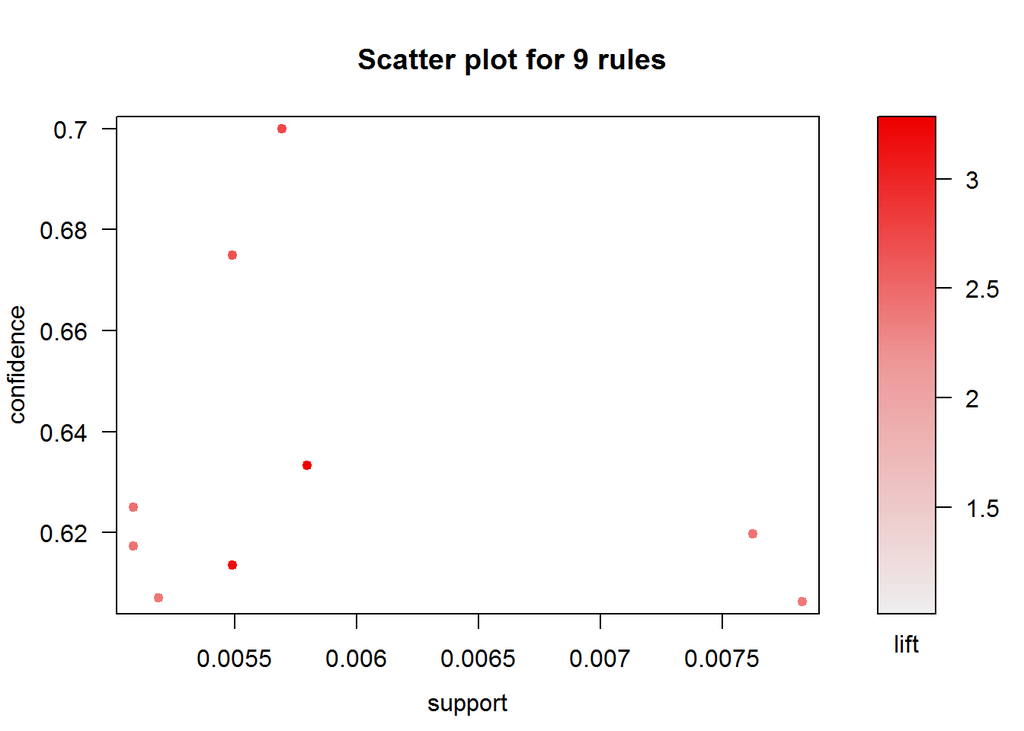

```r
plot(milk_rules, type = "scatterplot")
```

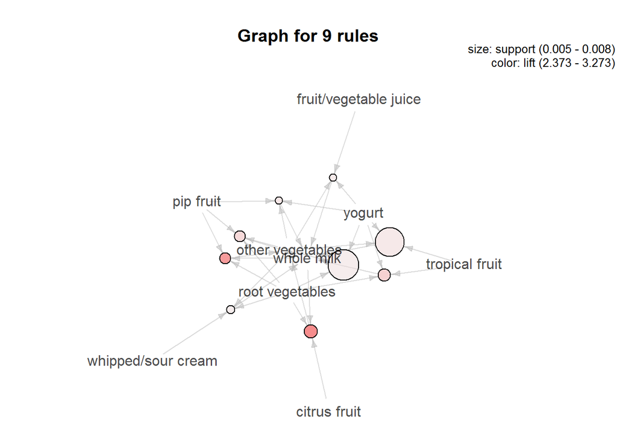

```r
plot(milk_rules, method = "graph")
```

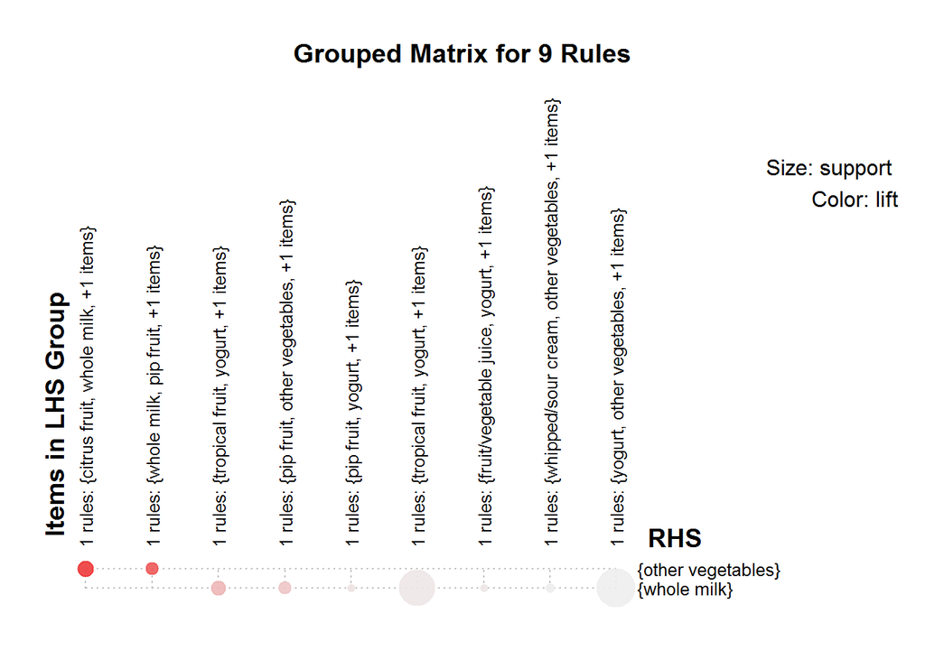

```r
plot(milk_rules, method = "grouped")
```